# Native European ants can discourage host colonization and reduce reproductive success of the invasive ambrosia beetle Xylosandrus compactus - ScienceDirect

[figure not shown]

## Outline

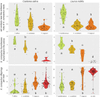

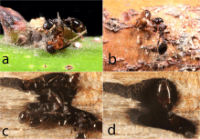

[figure not shown]

## [Biological Control](https://www.sciencedirect.com/journal/biological-control)

Available online 24 August 2022, 105032

[In Press, Journal Pre-proof](https://www.sciencedirect.com/journal/biological-control/articles-in-press)

# Native European ants can discourage host colonization and reduce reproductive success of the invasive ambrosia beetle *Xylosandrus compactus*

[DanieleGiannetti<sup>a</sup><sup>1</sup>](https://www.sciencedirect.com/science/article/abs/pii/S1049964422001979?via%3Dihub#!)[EnricoSchifani<sup>a</sup><sup>1</sup>](https://www.sciencedirect.com/science/article/abs/pii/S1049964422001979?via%3Dihub#!)[AntonioGugliuzzo<sup>b</sup><sup>1</sup>](https://www.sciencedirect.com/science/article/abs/pii/S1049964422001979?via%3Dihub#!)[LuciaZappalà<sup>b</sup>](https://www.sciencedirect.com/science/article/abs/pii/S1049964422001979?via%3Dihub#!)[AntonioBiondi<sup>b</sup>](https://www.sciencedirect.com/science/article/abs/pii/S1049964422001979?via%3Dihub#!)[Donato A.Grasso<sup>a</sup>](https://www.sciencedirect.com/science/article/abs/pii/S1049964422001979?via%3Dihub#!)

https://doi.org/10.1016/j.biocontrol.2022.105032[Get rights and content](https://s100.copyright.com/AppDispatchServlet?publisherName=ELS&contentID=S1049964422001979&orderBeanReset=true)

## Highlights

**•**

Four European ant species exhibited potential in predating *Xylosandrus compactus* juveniles.

**•**

*Temnothorax affinis* is able to enter galleries and prey beetles.

**•**

Dispersing beetle females avoid infesting twigs previously patrolled by ants.

**•**

Biocontrol services provided by the tested ants need consideration in further field studies.

## Abstract

Due to their ubiquity and their nature as generalist predators, ants have long been used as biological control agents in forest and agricultural systems. Several exotic ambrosia beetles (Coleoptera: Curculionidae: Scolytinae, Platypodinae) are considered emerging widespread pests of various trees and shrubs growing in forests, nurseries, orchards, and urban areas. Among them, the Scolytinae *Xylosandrus compactus* (Eichhoff) is an invasive fungus-farming species native to Asia and able to cause serious damage to a broad range of natural and cultivated plants worldwide, exerting significant ecological and economic costs. Its biology makes conventional control strategies often ineffective, while little is known about natural enemies. We explored the potential of native European predators as natural enemy of this pest, conducting laboratory tests with four widespread ant species using chestnut and laurel as beetle hosts. In particular, we evaluated the interactions between *X. compactus* and four species of native Euro-Mediterranean ants that usually forage on plants: *Crematogaster scutellaris* (Olivier), *Tapinoma magnum* Mayr, *Temnothorax affinis* (Mayr), and *Temnothorax mediterraneus* Ward, Brady, Fisher & Schultz. Results indicate that ants may significantly limit the reproductive success of *X. compactus*, increasing the mortality of the beetle foundresses and reducing their offspring. Smaller ant species may also invade *X. compactus* nests, killing larvae, pupae and adults, while female beetles avoid nesting in twigs previously visited by ants. These results encourage to explore possible applications of ants in the biological control of *X. compactus* and the ecological implications of these interactions in the field.

## Keywords

Biological control

Black twig borer

Hymenoptera

Formicidae

Invasive pest

Predators

## Cited by (0)

**<sup>1</sup>**

these authors contributed equally

[View full text](https://www.sciencedirect.com/science/article/pii/S1049964422001979)

© 2022 Elsevier Inc. All rights reserved.

## Part of special issue:

[SI: Biological control introductions against invasive species in support of agriculture and conservation](https://www.sciencedirect.com/science/journal/10499644/vsi/10J66RW7P9V)Edited by Emilio Guerrieri, George Heimpel, Ruth Hufbauer, Lessando M. Gontijo, Xingeng Wang

[figure not shown]